# Voting in the United Nations General Assembly (plus some other bits and bobs)

# Getting started and checking back over what we know so far

- Begin by **opening RStudio and re-opening your project folder** from last time (if it’s not already open) - top right of the RStudio window.
- Ideally we’ll use this one project folder for all our computer labs, building up R scripts in it.
- Then **make a new script** for this week’s work. (File / new file / r script OR press CTRL+SHIFT+N)

## Downloading data - getting this week’s CSV from Blackboard

So far we’ve only acquired data by loading it from the internet. We also want to be able to **download data and keep it stored in our project folder**.

- Before we download the data, let’s make a **‘data’ folder** in our project to store all of our data files:
- In the bottom right, **click on the Files tab** to show you what files are in the project folder.
- There’s a **new folder** button - click that and **make a new folder called ‘data’** (You should now see this in your file list.)
- Go to this week’s blackboard and find the **unvoting.csv** file. Click to download.
- We’ll need to move it from the download folder to our data folder - different for macs and windows.
- To help, in RStudio, in the **files** pane, click on **‘more’** and choose **‘show folder in new window’**. This will bring up explorer (or finder on mac) showing the project folder, including your new data folder.
- We can now copy or move from the download folder to the data folder.
- **In windows:** select the file in downloads, then CTRL + X to cut, go to the data folder and CTRL+V to paste. (Or just drag and drop.) Windows may also give you the option of downloading to specific folder, depending on browser.
- **On macs:** CMD + C to copy. Then CMD + V to paste (leaving copy behind) or, to move it, OPTION/ALT + CMD + V. (Or again you can drag and drop.)

**Check you’ve now got the downloaded csv file in your project’s data folder.**

You can actually view the raw file via the file tab: click on the file name then choose ‘view file’. As you can see, it is just variables separated by commas, nothing else.

Now we have the data locally, **we can read the CSV file into a dataframe**. Note: **now the file is local, RStudio will help with autocompleting file names**. Just type this and **press CTRL + SPACE after the forward slash** to bring up an autocomplete list. Use mouse, or press tab or enter to select.

```r
un <- read.csv('data/')
```

The full line will look like:

```r
un <- read.csv('data/unvoting.csv')
```

> **You can also download the metal bands csv from this week’s Blackboard page, if the URL isn’t working. We’ll look at this example in a moment.**

## Recap

So - a quick recap of where we got to. Read the code comments here:

```r
#R commmands will output to the console
8+2
```

```
## [1] 10
```

```r
#No commands are stored UNLESS YOU ASSIGN THEM TO A VARIABLE.
#That's true for EVERYTHING in R. Unless we ASSIGN it, it's not stored.
#For example:
sum <- 8 + 2

#If you assign something to the same variable name, it will overwrite the previous assignment
sum <- 11 + 6
```

..

Something that’s come up a few times - if R thinks a line of code isn’t completed, **you will see a plus (+) in the console**. That’s R saying it’s **waiting for another bit of code**. It will happen, for instance, if you try to run something like this:

```r
sqrt(100
```

… because a bracket is missing off the end.

The ‘plus’ thing can happen for a few reasons:

1. As above, there’s actually a missing bit of code, e.g. a missing bracket
2. You haven’t correctly highlighted all the code when you’re trying to run it
3. You’ve got code split over a number of lines but have only run one line of it

The solution will depend on which of those it is. But you can either:

1. Go to the console and press escape. That will get rid of the plus.
2. Add in the next bit of code R is expecting. It’s usually easier to do number one - that means you have to make sure a whole code chunk is working properly.

### Dataframes

Looking at the metal bands example now, too. We’ve seen how to **load a CSV from the internet into a dataframe**:

```r
#Load data via URL
metalbands <- read.csv(url('https://bit.ly/metalbandcsv'))
```

And that **dataframe columns can be referred to either by putting a dollar sign after the dataframe name, followed the column name**, or **indexing the column number directly using square brackets** (where the first index is row and second is column, and we leave blank if we want a whole row or column):

```r
#These do the same thing
metalbands$country
metalbands[,1]
```

We’ve **looked at the dataframe by clicking on its name in the environment panel**, and seen how to order columns there. (Though this doesn’t affect the underlying dataframe’s order.)

We’ve seen that you can **use dataframe columns to carry out calculations.** So if we want to find metal bands per head of population, we take the **number of metal bands per country** and **divide by the country’s population**.

Note here again, if we don’t assign to a new variable, R just outputs to the console:

```r
metalbands$metalbandcount/metalbands$population
```

So if we want to assign to the dataframe, we **make a new dataframe column** and assign to that:

```r
metalbands$bandspercapita <- metalbands$metalbandcount/metalbands$population
```

And can then **look at it by clicking on the dataframe in the environment panel.**

Note, for very small numbers and very large numbers, R will use **scientific notation** by default. If we don’t want this behaviour, we can **set scipen to some high value** like 99:

```r
options(scipen = 99)
```

And then numbers when we view the dataframe will be easier to read.

We could also actually **reorder the dataframe by our new metal bands per capita column** and then use the head function to see the top few.

Note again, **without assignment, R will just output to the console**:

```r
#Order the metalbands dataframe by the bandspercapita column, descending order indicated by the minus
metalbands[order(-metalbands$bandspercapita),]
```

If we want to keep the newly ordered dataframe, we can either assign to a new name, or **overwrite the metalbands dataframe with the new, ordered version**:

```r
#Overwrite the original dataframe with the new, ordered version
metalbands <- metalbands[order(-metalbands$bandspercapita),]

#Look at the top 10 rows
head(metalbands, 10)
```

## HELP!

In R, you can read a help file for any function. We’re going to be using a function called **subset**, so let’s look at the help file for that.

```r
?subset
```

Things we see here worth noticing:

- ‘Method for class ’dataframe’ - when we use subset on a dataframe, as we will be doing, these are the arguments we can pass to it.
- Notice the **order** of those arguments. We’ll come back to that.
- Below that, each argument is explained (these will make more sense with time and practice)
- **Details** will often explain in more depth how the function works and what some values are that the arguments take
- **Value** is **what the function outputs**. So in this case, it **outputs a subset of the inputted dataframe**
- Right at the bottom of the help page, there are **examples of how to use it**

So, as an example of how to use it - the UN voting data covers many years. We can get a list of all the years with:

```r
unique(un$Year)
```

```
##  [1] 1946 1947 1948 1949 1950 1951 1952 1953 1954 1955 1956 1957 1958 1959 1960
## [16] 1961 1962 1963 1965 1966 1967 1968 1969 1970 1971 1972 1973 1974 1975 1976
## [31] 1977 1978 1979 1980 1981 1982 1983 1984 1985 1986 1987 1988 1989 1990 1991
## [46] 1992 1993 1994 1995 1996 1997 1998 1999 2000 2001 2002 2003 2004 2005 2006
## [61] 2007 2008 2009 2010 2011 2012
```

Say we just wanted the year 2012:

```r
subset(x = un, subset = (Year == 2012))
```

Now - a useful point about functions: **if you pass arguments into the function in the order they’re listed in the help file, you don’t need to say which argument is which.** This makes for tidier code. E.g because the “x” and “subset” arguments are first and second, we can just do this:

```r
subset(un, Year == 2012)
```

Note: as always, there’s more than one way to do this in R. You can also use square brackets (though here, you need the **full column name, including the dataframe name**) - so, we just apply our logical operator to the rows (selecting all columns by leaving the column index blank):

```r
un[un$Year == 2012,]
```

# Note on Z scores and ‘normalising’ data

This will come up later with one of our UN data columns.

We discussed **Z scores** in the lecture briefly - a Z score for a single value is its **distance from the mean in standard deviations.** We find this by (a) *subtracting the mean from each observation* and (b) *dividing by the standard deviation*. For our M&Ms guesses, this looks like the following:

```r
guesses <- c(675,972,572,316,1500,2500,700,2500,387,310,750,507,345)

#Z score: subtract mean of all guesses from each guess, then divide the lot by the standard deviation
zscores <- (guesses - mean(guesses))/sd(guesses)
```

These Z scorees look like this:

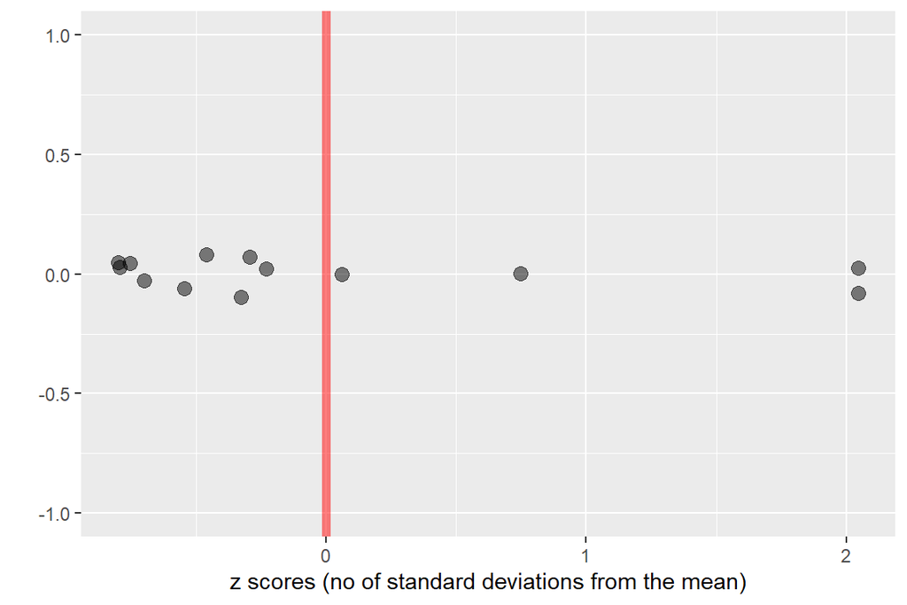

Finding Z scores for a whole vector like this has the effect of **standardising** or **scaling** the variable. This means that, for all Z score values together:

- **The mean will zero** (or very close to)
- **The standard deviation of the whole lot will be one** (or very close to)

```r
mean(zscores)
```

```
## [1] -0.000000000000000006405133
```

```r
sd(zscores)
```

```
## [1] 1
```

So, we have **scaled the data** so that its **values match what the standard deviation values in a normal distribution are.** Meaning - the new, adjusted values will match the standard deviation scale on the bottom of this (assuming the data is normally distributed):

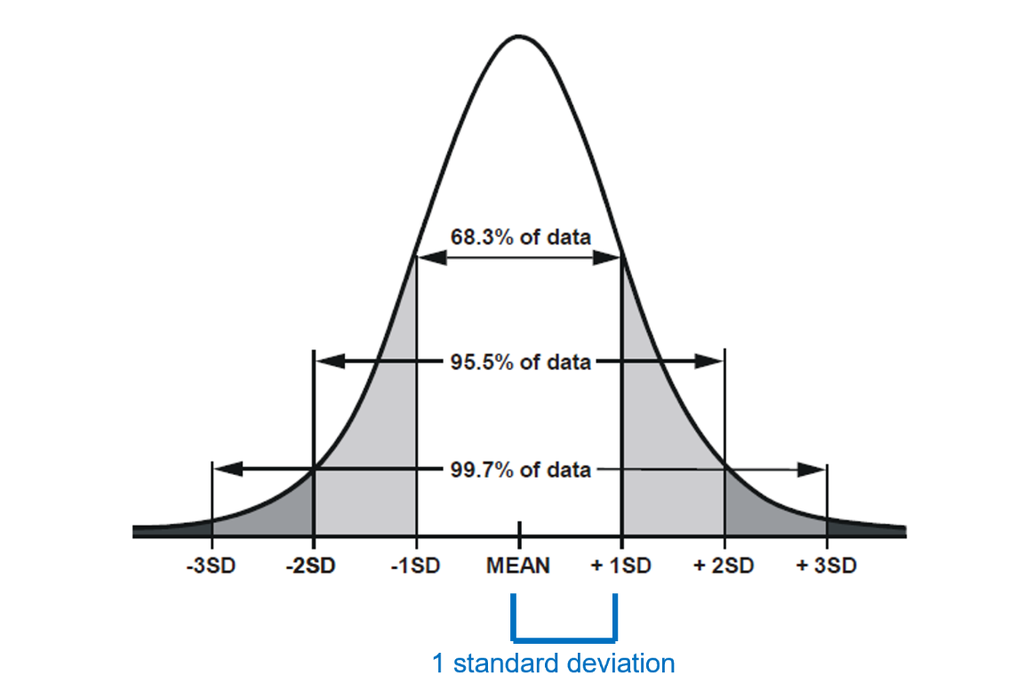

This normalising or **scaling** is often used for standardising scores, and for other statistical purposes. We’ll see it crop up a few times - including with the data below.

Note: **the R function `scale` achieves the same thing as manually creating our Z scores** (if we use its defaults):

```r
zscores2 <- scale(guesses)

mean(zscores2)
```

```
## [1] -0.00000000000000003682117
```

```r
sd(zscores2)
```

```
## [1] 1
```

# What’s your muddiest point? Jamboard…

> Let’s use a jamboard to note down what’s being the most difficult or confusing aspect of using R. [Here’s the link](https://jamboard.google.com/d/1dHypq_QbuBm01_yNBykX9EtNHQhndoxBIxED2NK7RCU/edit?usp=sharing) to the jamboard, if you’re looking at this on Blackboard. I’ve also emailed the link to you.

Use the ‘sticky note’ (fourth down on the left menu) to add a new note.

> Also feel free to just ask me - it’s likely anything that’s confusing you is confusing someone else too, it’d be good to share.

# Voting in the United Nations General Assembly

OK, now to **work with some actual data. Huzzah!** We loaded the CSV for this above. The plan:

- We’ll look at what the data is
- Then we’ll ask **five questions** of the data, and run through methods to answer them using R
- There’ll be **exercises for you to attempt as we work through them.**
- We probably won’t get through all five questions, so you can attempt the rest in your own time. If you want help and feedback.

Reminder on help:

- You can submit your work through Blackboard’s “weekly assignments” and I can check it (though I’m not going to force anyone, this is a great way for me to provide feedback)
- Use Piazza to ask questions
- Email me: d.olner@sheffield.ac.uk
- Use my feedback/consultation hours, Weds 9-11am. I can do in person or over google meet.

## The data

Like legislators in the US Congress, the member states of the United Nations (UN) are politically divided on many issues such as trade, nuclear disarmament, and human rights. During the Cold War, countries in the UN General Assembly tended to split into two factions: one led by the capitalist United States and the other by the communist Soviet Union.

**We will analyze how states’ ideological positions, as captured by their votes on UN resolutions, have changed since the fall of communism.**

This exercise is based on Michael A. Bailey, Anton Strezhnev, and Erik Voeten. “Estimating Dynamic State Preferences from United Nations Voting Data.” *Journal of Conflict Resolution*, August 2015.

In that paper, they “estimate state **ideal points** from 1946 to 2012 on a single dimension that reflects state positions toward the US-led liberal order”. (More on what **ideal points** are shortly.)

The data we downloaded to the *data* folder is called `unvoting.csv` and the variables are:

| Name | Description |
| --- | --- |
| `CountryName` | The name of the country |
| `idealpoint` | Its estimated ideal point |
| `Year` | The year for which the ideal point is estimated |
| `PctAgreeUS` | The percentage of votes that agree with the US on the same issue |
| `PctAgreeRUSSIA` | The percentage of votes that agree with Russia/the Soviet Union on the same issue |

In the analysis that follows, we measure state preferences in two ways. Note that the data for 1964 are missing due to the absence of roll call data.

In this data, the ideal point is a **single number**, so just a one-dimensional scale, with **“more liberal” countries at the top of the positive values.** It’s **roughly equivalent to a left-right political spectrum scale**.

This is a good summary of what ‘ideal points’ are: blogs.iq.harvard.edu/ideal_points_1

The ‘ideal point’ value captures this in one number: “a legislator will vote in favor of a motion if it moves policy outcomes closer to their most preferred policy” (represented by their ideal point).

The two measures are highly correlated, with larger (more liberal) ideal points corresponding to a higher percentage of votes that agree with the US.

..

First, let’s just **look at the UN data we loaded at the start using summary**:

```r
summary(un)
```

```
##       Year       CountryAbb        CountryName          idealpoint
##  Min.   :1946   Length:9120        Length:9120        Min.   :-2.6552
##  1st Qu.:1972   Class :character   Class :character   1st Qu.:-0.6406
##  Median :1987   Mode  :character   Mode  :character   Median :-0.1644
##  Mean   :1985                                         Mean   : 0.0000
##  3rd Qu.:2001                                         3rd Qu.: 0.7968
##  Max.   :2012                                         Max.   : 3.0144
##
##    PctAgreeUS     PctAgreeRUSSIA
##  Min.   :0.0000   Min.   :0.0000
##  1st Qu.:0.1395   1st Qu.:0.5053
##  Median :0.2400   Median :0.6567
##  Mean   :0.2960   Mean   :0.6219
##  3rd Qu.:0.3902   3rd Qu.:0.7424
##  Max.   :1.0000   Max.   :1.0000
##  NA's   :1        NA's   :5
```

What can we see about the dataframe’s variables from the summary?

## Question 1

We begin by examining **how the distribution of state ideal points has changed since the end of communism**. We will:

- Plot the distribution of ideal points separately for 1980 and 2000, by **getting a subset of those two years** - **about ten years before and after the fall of the Berlin Wall**.
- Add a median to each plot as a vertical line.
- Examine how the two distributions differ?
- We’ll pay attention to the degree of polarization and give a brief interpretation of the results.
- And finally, use the `quantile` function to quantify the patterns you identified.

**Let’s start with 1980, then you can have a go at doing the same for the year 2000**. We make a histogram with **hist**. Note the arguments it’s taking:

- xlim: this sets the limits of the x axis.
- xlab: labels the x axis.
- main: sets the main title.

```r
#Make a subset of the main dataset
un1980 <- subset(un, Year == 1980)

#Add our subsetted data to a histogram.
hist(un1980$idealpoint, xlim = c(-3, 3), xlab = "Ideal points", main = "1980")

#Add a vertical line to the histogram
abline(_ = _____)

quantile(un1980$idealpoint)
```

> EXERCISE: Repeat the same as above - produce a histogram, and add a vertical line where the median is - **but for the year 2000**. Then find the quantiles for that year.

Perhaps surprisingly, the fall of communism did not lead to ideological convergence across states. Rather, in 2000, most states clustered at around either 1 or -1. Although the range of the distribution moved in a more liberal direction (if we look at the quantile) the median UN member-state became less liberal over time.

## Quick aside: missing values

In R, **missing values are indicated by NA**. So, for example, if we didn’t know the final value in this vector, we’d put:

```r
x <- c(1,4,7,9,NA)
```

R handles missing values differently in different functions. Note what the behaviour of the **mean** function is:

```r
mean(x)
```

```
## [1] NA
```

Because there’s **one NA** in the data, the mean function just returns NA. However, we can tell the mean function to remove any missing values and **just find the mean for the non-missing values**:

```r
mean(x, na.rm = TRUE)
```

```
## [1] 5.25
```

Take a look in the ?help file for the `mean` function. Notice that it says “na.rm = FALSE” - the help files **show what the default for any argument is, if you don’t override it.**

## Question 2

Next, we examine how the number of countries voting with the US has changed over time. We will:

- Plot the average percent agreement with US across all counties over time.
- add the average percent agreement with Russia as another line for comparison.
- Ask: ** Does the US appear to be getting more or less isolated over time, as compared to Russia? ** What are some countries that are consistently pro-US? ** What are the most pro-Russian countries?

When plotting, we’ll want time x-axis based on years in the data. We can get all the **unique years** like this:

```r
years <- unique(un$Year)
```

We’re also going to **use a new function to find means for each year**. This function - `tapply` - does the following:

- Give it a dataframe, and the grouping variable for which you want a result per group (in this case, groups of years)
- Pass it the function you want to apply to each of the groups

For example, to find the **mean for each year, for the percent US agreement** (note, we pass an argument that removes NAs from what goes into the mean):

```r
tapply(un$PctAgreeUS, un$Year, mean, na.rm = TRUE)
```

```
##      1946      1947      1948      1949      1950      1951      1952      1953
## 0.5845618 0.6214449 0.5779681 0.5406456 0.6347067 0.4869926 0.5566342 0.4452379
##      1954      1955      1956      1957      1958      1959      1960      1961
## 0.4383941 0.4159428 0.6593600 0.5850612 0.6547923 0.4860999 0.5130678 0.4984090
##      1962      1963      1965      1966      1967      1968      1969      1970
## 0.4734424 0.4507305 0.4365220 0.4186460 0.4058780 0.3998737 0.4196201 0.4156041
##      1971      1972      1973      1974      1975      1976      1977      1978
## 0.4640570 0.4139799 0.3411645 0.3460560 0.3163592 0.2616777 0.3760745 0.3911719
##      1979      1980      1981      1982      1983      1984      1985      1986
## 0.3060411 0.2614370 0.2067520 0.1704590 0.1830039 0.1409880 0.1793110 0.1745452
##      1987      1988      1989      1990      1991      1992      1993      1994
## 0.1496998 0.1253368 0.1168723 0.1786069 0.2081850 0.2056402 0.2387228 0.3175991
##      1995      1996      1997      1998      1999      2000      2001      2002
## 0.2970175 0.3224666 0.2889927 0.2635592 0.2620113 0.2755106 0.2296708 0.1901075
##      2003      2004      2005      2006      2007      2008      2009      2010
## 0.2096395 0.1829842 0.1769182 0.1538170 0.1475810 0.1526457 0.2138378 0.2293089
##      2011      2012
## 0.2902717 0.2362693
```

So - now we have a vector of years, and we can find a mean value of the percent US agreement per year, these can go into a graph. Extra arguments going into plot here are:

- type: “l” (that’s a lower case “L”, if it’s not clear) sets the type to ‘line’ (the default is points)
- set the line colour to blue.

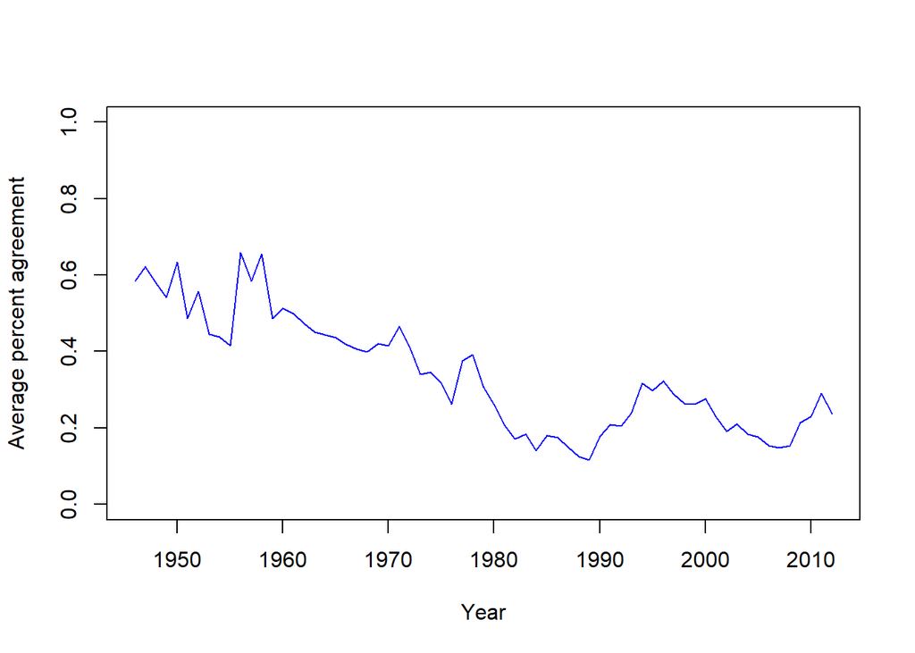

```r
plot(x = years, y = tapply(un$PctAgreeUS, un$Year, mean, na.rm = TRUE),
     ylim = c(0, 1), xlab = "Year", ylab = "Average percent agreement",
     type = "l", col = "blue")
```

> EXERCISE: We can **add more lines to the same plot** using the `lines` function. Say we want to **add a line showing the mean value of percent agreement with Russia for each year** - exactly as we just did with `tapply(un$PctAgreeUS, un$Year, mean, na.rm = TRUE)` - can you fill in the blank in the line below to add this to the function? You just need to change the column name from un$PctAgreeUS, otherwise the line is the same.

(We’ll also add a couple of text labels.)

```r
lines(x = years, y = _____, col = "red")

text(2000, 0.1, "Voting with US", col = "blue")
text(2000, 0.8, "Voting with Russia", col = "red")
```

**We can find the top 5 pro-US and pro-Russian countries (according to this measure) using the `sort` function.** This sorts plain vectors in order. For example:

```r
#Random vector of numbers
vec <- c(7,1,3,9,5)

#Sort (ascending order by default)
sort(vec)
```

```
## [1] 1 3 5 7 9
```

```r
#Sort (descending order)
sort(vec, decreasing = TRUE)
```

```
## [1] 9 7 5 3 1
```

We can combine stages in one code chunk to do the following:

- Use `tapply` to find the means for ‘percent agrees with…’
- Sort those values in descending order
- Only look at the top five (excluding the number one slot, because those are the USA and Russia, who of course agree with themselves a hundred percent!)

```r
sort(tapply(un$PctAgreeUS, un$CountryName, mean, na.rm = TRUE),
          decreasing = TRUE)[2:6] # first one is US itself
```

```
##                          Palau                 United Kingdom
##                      0.7356335                      0.6521001
##                         Taiwan                         Israel
##                      0.6430106                      0.6399077
## Federated States of Micronesia
##                      0.5937617
```

> EXERCISE: Repeat the same for ‘percent agreement with Russia’. What does this show?

## Question 3

One problem of using the percentage of votes that agree with the US or Russia as a measure of state preferences is that **the ideological positions, and consequently the voting patterns, of the US and Russia might have themselves changed over time.** This makes it difficult to know which countries’ ideological positions have changed.

- We’ll investigate this issue by **plotting the USA’s and Russia’s ‘ideal points’ over time**.
- We’ll add the yearly median ideal point of all countries.
- We’ll ask how the results of this analysis modify (or not) your interpretation of the previous analysis

We start with plotting the USA’s ideal points over time. This is all code you’ve used before - but note we’re **subsetting in the square brackets** to get **only the ideal points where the country is the USA**.

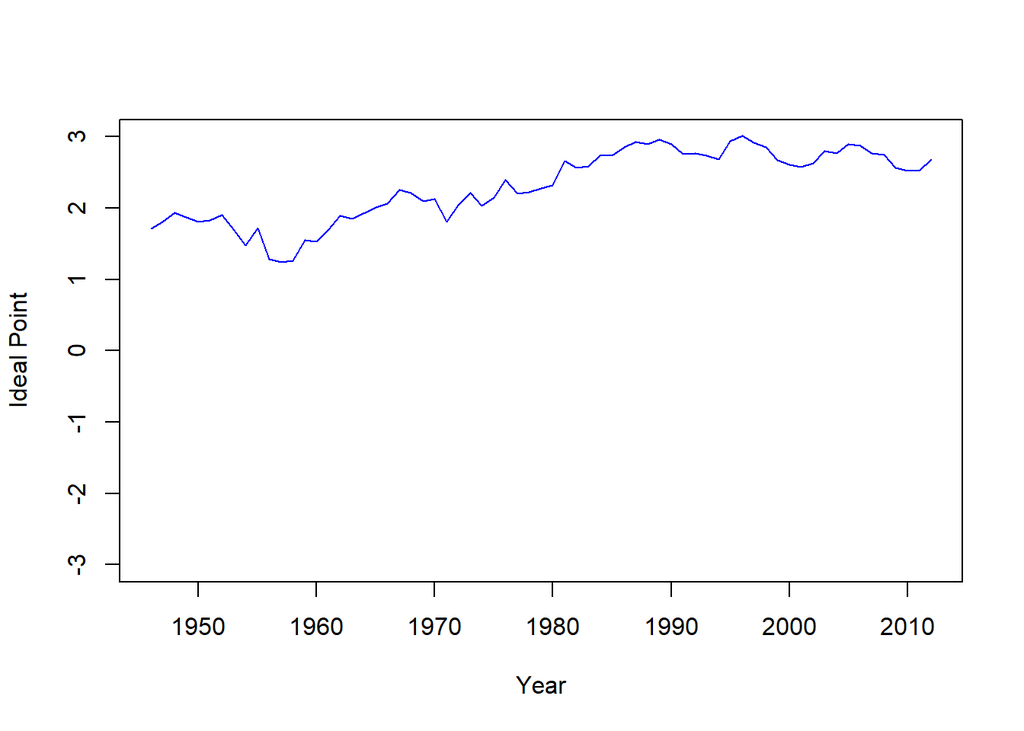

```r
plot(x = years, y = un$idealpoint[un$CountryAbb == "USA"],
     ylim = c(-3, 3), xlab = "Year", ylab = "Ideal Point",
     type = "l", col = "blue")
```

> EXERCISE: Now we want to add **two more lines.** The first just repeats what we did in the plot above, except **subsetting for Russia in the square brackets, rather than the USA**. (The Russian abbreviated code is RUS.) Add this where the blank is in the first line of code here.

> In the second ‘lines’ function, create another line giving the **median ‘ideal point’ for every year**, using the tapply method used above.

```r
lines(x = years, y = _____, col = "red")
lines(x = years, y = tapply(___, ___, ___))
```

Lastly, we can add some labels. Note: the `backslash-n` in the final line is a **line break** - it makes the text wrap to the next line.

```r
text(2010, 2, "US", col = "blue")
text(2010, 0.5, "Russia", col = "red")
text(2005, -1, "median of\n all countries")
```

Now we have this plot, can you respond to these questions?

- How has the US changed over time, relative to the median UN member state?
- How has Russia changed over time, relative to the median UN member state?
- What does this suggest about how we interpret the graph in question 2 above? Have countries been moving closer to Russia’s ideology (indicated by a higher average percent voting with Russia) or has something else been happening?

## Question 4

The download is an `rds` file - this is a compressed file that can store **any R object**, whether it’s a vector, a dataframe, a graphical plot - anything at all. See the code below on how to load it in.

Both of these options look like:

```r
#Manually input the vector
post.soviet <-
    c("Estonia", "Latvia", "Lithuania", "Belarus", "Moldova", "Ukraine",
      "Armenia", "Azerbaijan", "Georgia", "Kazakhstan", "Kyrgyzstan",
      "Tajikistan", "Turkmenistan", "Uzbekistan", "Russia")

#OR
#Having downloaded the vector and moved to your data folder in the project folder, load it into R.
post.soviet <- readRDS('data/postsovietcountries_vector.rds')
```

- Are each of the countries in our post.soviet vectors `%in%` the country list in the UN dataframe?

This would look like:

```r
post.soviet %in% un$CountryName
```

```
##  [1] TRUE TRUE TRUE TRUE TRUE TRUE TRUE TRUE TRUE TRUE TRUE TRUE TRUE TRUE TRUE
```

If you’ve got the right names, you should see a `TRUE` returned for each element of the `post.soviet` vector. This is useful, as it means we know there are exact name matches. We can use the same method to add a **flag** (or an ‘indicator variable’) to the UN dataframe telling us whether a country is post-Soviet or not. Note **the order is different here**. We’re now asking, for each country name in the dataframe, where that name is `%in%` the small vector we made/loaded.

**Once you’ve run this, view the data to confirm it’s worked and see what it’s done.**

```r
un$post.soviet <- un$CountryName %in% post.soviet
```

> EXERCISE: We’ll **focus on the most recently available UN data from 2012**. To do this, use subset to subset the UN dataframe to **just the year 2012**. Fill in the blank here:

```r
un12 <- subset(un, _____)
```

We’ll then **plot each Post-Soviet Union state’s ideal point against the percentage of its votes that agree with the United States.**

There’s an extra argument here: `pch`. We’re using the default to plot points (not lines). `pch` tells R **what kind of point to use.** You can **use the help** to see what kind of point the number will choose.

Notice that we’re **applying a logical operator in the square brackets** to filter down to just post-Soviet countries, using the flag we just made.

```r
plot(x = un12$idealpoint[un12$post.soviet == TRUE],
     y = un12$PctAgreeUS[un12$post.soviet == TRUE], pch = 16,
     xlim = c(-3, 3), ylim = c(0, 1), col = "red",
     xlab = "Ideal Points",
     ylab = "Proportion of Votes Agreeing with US")
```

> EXERCISE: Next we use the **points** function to add other countries to the same plot. Just fill in the blanks - same code as above, but we want the `post.soviet` flag set to subset `FALSE` instead.

And we add some labels to finish.

```r
points(x = ___,
       y = ___, pch = 17,
       col = "blue")

text(1.5, 0.2, "Post-Soviet States", col = "red")
text(1, 0.8, "Other Countries", col = "blue")
```

Any thoughts on this graph?

## Question 5

For the last question, let’s examine how the median ideal points of Soviet/post-Soviet countries and all other countries has varied over all the years in the data. What we want to know:

- **Did the ‘ideal point’ for post-Soviet states change after the fall of the Berlin wall in 1989 (relative to other countries)?**

We’ll do the following:

- Create two subsetted dataframes, one for post-Soviet countries and one for all others (using the flag we made above)
- Plot each of these using lines: we want to plot **years on the x axis (as we did in question 2 and 3)** and **median idealpoint per year, using the tapply function, on a y axis**.
- Plot a vertical line to indicate where 1989 is.

> EXERCISE: The first part of the plot is in the code below. Please fill in the blanks in the `lines` function to add the post-soviet countries. Please also **complete the abline function to add a line for the year the Berlin wall came down.**

```r
#First, create two subsetted dataframes for post-Soviet countries and the rest
post.soviet.un <- subset(un, post.soviet == TRUE)
no.soviet.un <- subset(un, post.soviet == FALSE)


plot(x = years,
     y = tapply(no.soviet.un$idealpoint, no.soviet.un$Year, median),
     type = "l", ylim = c(-3, 3), xlab = "Year", ylab = "Ideal point")

lines(____,
      ____,
      col = "red")

abline(___, lty = "dashed")

text(1995, -0.8, "Other States")
text(1995, 1, "Soviet/Post-Soviet States", col = "red")
```

What do you observe?